# Lab_10_Metagenomics_MBI3100A_2022_Tutorial

2022-11-12

# Install required libraries

Installing these libraries may take some time. Try to update all other dependencies when prompted (type “a” and enter).

```r
if (!require("BiocManager")) install.packages("BiocManager")
if (!require("phyloseq")) BiocManager::install("phyloseq")
if (!require("tidyverse")) install.packages("tidyverse")
if (!require("DT")) install.packages("DT")
if (!require("dendextend")) install.packages("dendextend")
```

[output not shown]

# Load Libraries

```r
library(phyloseq)
library(ggplot2)
library(dplyr)
library(DT)
library(dendextend)
```

# List of packages available in phyloseq

Phyloseq come with preloaded datasets. The datasets can be explored using the following commands. The column named “Item” contains the list of all the datasets available in phyloseq package

```r
phyloseq_datasets = data(package = "phyloseq")
phyloseq_datasets$results
```

```
##      Package    LibPath                                       Item
## [1,] "phyloseq" "C:/Users/HP/AppData/Local/R/win-library/4.2" "GlobalPatterns"
## [2,] "phyloseq" "C:/Users/HP/AppData/Local/R/win-library/4.2" "enterotype"
## [3,] "phyloseq" "C:/Users/HP/AppData/Local/R/win-library/4.2" "esophagus"
## [4,] "phyloseq" "C:/Users/HP/AppData/Local/R/win-library/4.2" "soilrep"
##      Title
## [1,] "(Data) Global patterns of 16S rRNA diversity at a depth of millions of sequences per sample (2011)"
## [2,] "(Data) Enterotypes of the human gut microbiome (2011)"
## [3,] "(Data) Small example dataset from a human esophageal community (2004)"
## [4,] "(Data) Reproducibility of soil microbiome data (2011)"
```

# Readable data table in Rmarkdown

```r
phyloseq_datasets$results %>% DT::datatable()
```

| Package | LibPath | Item | Title |
| --- | --- | --- | --- |
| phyloseq | C:/Users/HP/AppData/Local/R/win-library/4.2 | GlobalPatterns | (Data) Global patterns of 16S rRNA diversity at a depth of millions of sequences per sample (2011) |
| phyloseq | C:/Users/HP/AppData/Local/R/win-library/4.2 | enterotype | (Data) Enterotypes of the human gut microbiome (2011) |
| phyloseq | C:/Users/HP/AppData/Local/R/win-library/4.2 | esophagus | (Data) Small example dataset from a human esophageal community (2004) |
| phyloseq | C:/Users/HP/AppData/Local/R/win-library/4.2 | soilrep | (Data) Reproducibility of soil microbiome data (2011) |

```r
# To load the GlobalPatterns dataset
data(GlobalPatterns)
```

```r
GlobalPatterns
```

```
## phyloseq-class experiment-level object
## otu_table()   OTU Table:         [ 19216 taxa and 26 samples ]
## sample_data() Sample Data:       [ 26 samples by 7 sample variables ]
## tax_table()   Taxonomy Table:    [ 19216 taxa by 7 taxonomic ranks ]
## phy_tree()    Phylogenetic Tree: [ 19216 tips and 19215 internal nodes ]
```

# Interpretation

GlobalPatterns is a phyloseq object which contains 1 out_table, 1 sample_data table, 1 taxonomy table and 1 phylogenetic tree.

We can access the different data type of data and table using following commands

```r
# otu_table()
# sample_data()
# tax_table()
# phy_tree()
```

# Question: How many samples are there in the ‘GlobalPatterns’ data set? (1 mark)

```markdown
Answer: 26
```

# Access the OTU table from a dataset

```r
otu_table(GlobalPatterns) %>%  head()
```

```
## OTU Table:          [6 taxa and 26 samples]
##                      taxa are rows
##        CL3 CC1 SV1 M31Fcsw M11Fcsw M31Plmr M11Plmr F21Plmr M31Tong M11Tong
## 549322   0   0   0       0       0       0       0       0       0       0
## 522457   0   0   0       0       0       0       0       0       0       0
## 951      0   0   0       0       0       0       1       0       0       0
## 244423   0   0   0       0       0       0       0       0       0       0
## 586076   0   0   0       0       0       0       0       0       0       0
## 246140   0   0   0       0       0       0       0       0       0       0
##        LMEpi24M SLEpi20M AQC1cm AQC4cm AQC7cm NP2 NP3 NP5 TRRsed1 TRRsed2
## 549322        0        1     27    100    130   1   0   0       0       0
## 522457        0        0      0      2      6   0   0   0       0       0
## 951           0        0      0      0      0   0   0   0       0       0
## 244423        0        0      0     22     29   0   0   0       0       0
## 586076        0        0      0      2      1   0   0   0       0       0
## 246140        0        0      0      1      3   0   0   0       0       0
##        TRRsed3 TS28 TS29 Even1 Even2 Even3
## 549322       0    0    0     0     0     0
## 522457       0    0    0     0     0     0
## 951          0    0    0     0     0     0
## 244423       0    0    0     0     0     0
## 586076       0    0    0     0     0     0
## 246140       0    0    0     0     0     0
```

Read the table with as.data.frame( )

```r
otu_table(GlobalPatterns)[1:5, 1:5]
```

```
## OTU Table:          [5 taxa and 5 samples]
##                      taxa are rows
##        CL3 CC1 SV1 M31Fcsw M11Fcsw
## 549322   0   0   0       0       0
## 522457   0   0   0       0       0
## 951      0   0   0       0       0
## 244423   0   0   0       0       0
## 586076   0   0   0       0       0
```

```r
sample_data(GlobalPatterns) %>% DT::datatable()
```

|  | X.SampleID | Primer | Final_Barcode | Barcode_truncated_plus_T | Barcode_full_length | SampleType | Description |
| --- | --- | --- | --- | --- | --- | --- | --- |
| CL3 | CL3 | ILBC_01 | AACGCA | TGCGTT | CTAGCGTGCGT | Soil | Calhoun South Carolina Pine soil, pH 4.9 |
| CC1 | CC1 | ILBC_02 | AACTCG | CGAGTT | CATCGACGAGT | Soil | Cedar Creek Minnesota, grassland, pH 6.1 |
| SV1 | SV1 | ILBC_03 | AACTGT | ACAGTT | GTACGCACAGT | Soil | Sevilleta new Mexico, desert scrub, pH 8.3 |
| M31Fcsw | M31Fcsw | ILBC_04 | AAGAGA | TCTCTT | TCGACATCTCT | Feces | M3, Day 1, fecal swab, whole body study |
| M11Fcsw | M11Fcsw | ILBC_05 | AAGCTG | CAGCTT | CGACTGCAGCT | Feces | M1, Day 1, fecal swab, whole body study |
| M31Plmr | M31Plmr | ILBC_07 | AATCGT | ACGATT | CGAGTCACGAT | Skin | M3, Day 1, right palm, whole body study |
| M11Plmr | M11Plmr | ILBC_08 | ACACAC | GTGTGT | GCCATAGTGTG | Skin | M1, Day 1, right palm, whole body study |
| F21Plmr | F21Plmr | ILBC_09 | ACACAT | ATGTGT | GTAGACATGTG | Skin | F1, Day 1, right palm, whole body study |
| M31Tong | M31Tong | ILBC_10 | ACACGA | TCGTGT | TGTGGCTCGTG | Tongue | M3, Day 1, tongue, whole body study |
| M11Tong | M11Tong | ILBC_11 | ACACGG | CCGTGT | TAGACACCGTG | Tongue | M1, Day 1, tongue, whole body study |

[output cut: 16 more lines]

# Access the sample data table and the column content from a dataset

```r
# To access the variables in the column 'SampleType'
# The column 'SampleType' is of class factor so get the levels using the command
sample_data(GlobalPatterns)$SampleType %>% levels()
```

```
## [1] "Feces"              "Freshwater"         "Freshwater (creek)"
## [4] "Mock"               "Ocean"              "Sediment (estuary)"
## [7] "Skin"               "Soil"               "Tongue"
```

Read with as.data.frame

```r
sample_data(GlobalPatterns)$SampleType %>% levels() %>% as.data.frame()
```

```
##                    .
## 1              Feces
## 2         Freshwater
## 3 Freshwater (creek)
## 4               Mock
## 5              Ocean
## 6 Sediment (estuary)
## 7               Skin
## 8               Soil
## 9             Tongue
```

# How many sample types are available under the SampleType column?

```markdown
Answer: 9, "Feces", "Freshwater", "Freshwater (creek)", "Mock", "Ocean"     "Sediment (estuary)", "Skin", "Soil", "Tongue"
```

```r
tax_table(GlobalPatterns) %>% head() %>% DT::datatable()
```

|  | Kingdom | Phylum | Class | Order | Family | Genus | Species |
| --- | --- | --- | --- | --- | --- | --- | --- |
| 549322 | Archaea | Crenarchaeota | Thermoprotei |  |  |  |  |
| 522457 | Archaea | Crenarchaeota | Thermoprotei |  |  |  |  |
| 951 | Archaea | Crenarchaeota | Thermoprotei | Sulfolobales | Sulfolobaceae | Sulfolobus | Sulfolobusacidocaldarius |
| 244423 | Archaea | Crenarchaeota | Sd-NA |  |  |  |  |
| 586076 | Archaea | Crenarchaeota | Sd-NA |  |  |  |  |
| 246140 | Archaea | Crenarchaeota | Sd-NA |  |  |  |  |

```r
tax_table(GlobalPatterns) %>% head()
```

```
## Taxonomy Table:     [6 taxa by 7 taxonomic ranks]:
##        Kingdom   Phylum          Class          Order          Family
## 549322 "Archaea" "Crenarchaeota" "Thermoprotei" NA             NA
## 522457 "Archaea" "Crenarchaeota" "Thermoprotei" NA             NA
## 951    "Archaea" "Crenarchaeota" "Thermoprotei" "Sulfolobales" "Sulfolobaceae"
## 244423 "Archaea" "Crenarchaeota" "Sd-NA"        NA             NA
## 586076 "Archaea" "Crenarchaeota" "Sd-NA"        NA             NA
## 246140 "Archaea" "Crenarchaeota" "Sd-NA"        NA             NA
##        Genus        Species
## 549322 NA           NA
## 522457 NA           NA
## 951    "Sulfolobus" "Sulfolobusacidocaldarius"
## 244423 NA           NA
## 586076 NA           NA
## 246140 NA           NA
```

```r
GP_tutorial_1 <- subset_taxa(GlobalPatterns, Species!="NA")
GP_tutorial_1
```

```
## phyloseq-class experiment-level object
## otu_table()   OTU Table:         [ 1413 taxa and 26 samples ]
## sample_data() Sample Data:       [ 26 samples by 7 sample variables ]
## tax_table()   Taxonomy Table:    [ 1413 taxa by 7 taxonomic ranks ]
## phy_tree()    Phylogenetic Tree: [ 1413 tips and 1412 internal nodes ]
```

# Import data

We will combine a phyloseq object using otu_table, sample_data and taxonomy file. Will will read these three file and then combine them to make a phyloseq object to work with them,

```r
#data_dir =
```

## OTU table

```r
# To import otus column as rownames, as required by phyloseq
GP_sp_tutorial_otu_table = read.table("./tutorial_files/GP_sp_tutorial_otu_table_df.csv",
           sep = "\t",
           header =  T,
           row.names = "otus")
GP_sp_tutorial_otu_table[1:5, 1:5]
```

```
##        M31Plmr M11Plmr F21Plmr M31Tong M11Tong
## 951          0       1       0       0       0
## 155495       0       0       0       0       0
## 1029         0       0       0       0       0
## 341551       0       0       0       0       0
## 108964       0       2       6       1       0
```

## Sample data

```r
# Import with sampleid column as rownames, as required by phyloseq
GP_sp_tutorial_sample_data = read.table("./tutorial_files/GP_sp_tutorial_sample_data_df.csv",
           sep = "\t", header =  T,
           row.names = "sampleid")
GP_sp_tutorial_sample_data %>% head()
```

```
##          SampleOrigin X.SampleID  Primer Final_Barcode Barcode_truncated_plus_T
## M31Plmr         Human    M31Plmr ILBC_07        AATCGT                   ACGATT
## M11Plmr         Human    M11Plmr ILBC_08        ACACAC                   GTGTGT
## F21Plmr         Human    F21Plmr ILBC_09        ACACAT                   ATGTGT
## M31Tong         Human    M31Tong ILBC_10        ACACGA                   TCGTGT
## M11Tong         Human    M11Tong ILBC_11        ACACGG                   CCGTGT
## LMEpi24M   Freshwater   LMEpi24M ILBC_13        ACACTG                   CAGTGT
##          Barcode_full_length SampleType
## M31Plmr          CGAGTCACGAT       Skin
## M11Plmr          GCCATAGTGTG       Skin
## F21Plmr          GTAGACATGTG       Skin
## M31Tong          TGTGGCTCGTG     Tongue
## M11Tong          TAGACACCGTG     Tongue
## LMEpi24M         CATGAACAGTG Freshwater
##                                           Description
## M31Plmr       M3, Day 1, right palm, whole body study
## M11Plmr      M1, Day 1, right palm, whole body study
## F21Plmr     F1, Day 1,  right palm, whole body study
## M31Tong          M3, Day 1, tongue, whole body study
## M11Tong          M1, Day 1, tongue, whole body study
## LMEpi24M Lake Mendota Minnesota, 24 meter epilimnion
```

## Taxonomy table

```r
# To import otus column as rownames, as required by phyloseq
GP_sp_tutorial_tax_table = read.table("./tutorial_files/GP_sp_tutorial_tax_table_df.csv",
           sep = "\t",
           header =  T,
           row.names = "otus")
GP_sp_tutorial_tax_table %>% head()
```

```
##        Kingdom        Phylum          Class         Order         Family
## 951    Archaea Crenarchaeota   Thermoprotei  Sulfolobales  Sulfolobaceae
## 155495 Archaea Crenarchaeota Thaumarchaeota Cenarchaeales Cenarchaeaceae
## 1029   Archaea Crenarchaeota Thaumarchaeota Cenarchaeales Cenarchaeaceae
## 341551 Archaea Crenarchaeota Thaumarchaeota Cenarchaeales Cenarchaeaceae
## 108964 Archaea Crenarchaeota Thaumarchaeota Cenarchaeales Cenarchaeaceae
## 330416 Archaea Crenarchaeota Thaumarchaeota Cenarchaeales Cenarchaeaceae
##                 Genus                  Species
## 951        Sulfolobus Sulfolobusacidocaldarius
## 155495    Cenarchaeum     Cenarchaeumsymbiosum
## 1029      Cenarchaeum     Cenarchaeumsymbiosum
## 341551 Nitrosopumilus                   pIVWA5
## 108964 Nitrosopumilus                   pIVWA5
## 330416 Nitrosopumilus                   pIVWA5
```

## In order to read the OTU table as phyloseq object

```r
my_OTU_table = otu_table(GP_sp_tutorial_otu_table, taxa_are_rows = TRUE)
my_OTU_table %>% head()
```

```
## OTU Table:          [6 taxa and 10 samples]
##                      taxa are rows
##        M31Plmr M11Plmr F21Plmr M31Tong M11Tong LMEpi24M SLEpi20M AQC1cm AQC4cm
## 951          0       1       0       0       0        0        0      0      0
## 155495       0       0       0       0       0        0        0      0      0
## 1029         0       0       0       0       0        0        0      0      0
## 341551       0       0       0       0       0        0        0      0      0
## 108964       0       2       6       1       0        1        0      1      0
## 330416       0       0       0       0       0        0        0      0      0
##        AQC7cm
## 951         0
## 155495      0
## 1029        0
## 341551      0
## 108964      1
## 330416      0
```

### Similarly to read sample data and taxonomy table as phyloseq objects

```r
my_Sample_data = sample_data(GP_sp_tutorial_sample_data)
my_Sample_data %>% head()
```

```
##          SampleOrigin X.SampleID  Primer Final_Barcode Barcode_truncated_plus_T
## M31Plmr         Human    M31Plmr ILBC_07        AATCGT                   ACGATT
## M11Plmr         Human    M11Plmr ILBC_08        ACACAC                   GTGTGT
## F21Plmr         Human    F21Plmr ILBC_09        ACACAT                   ATGTGT
## M31Tong         Human    M31Tong ILBC_10        ACACGA                   TCGTGT
## M11Tong         Human    M11Tong ILBC_11        ACACGG                   CCGTGT
## LMEpi24M   Freshwater   LMEpi24M ILBC_13        ACACTG                   CAGTGT
##          Barcode_full_length SampleType
## M31Plmr          CGAGTCACGAT       Skin
## M11Plmr          GCCATAGTGTG       Skin
## F21Plmr          GTAGACATGTG       Skin
## M31Tong          TGTGGCTCGTG     Tongue
## M11Tong          TAGACACCGTG     Tongue
## LMEpi24M         CATGAACAGTG Freshwater
##                                           Description
## M31Plmr       M3, Day 1, right palm, whole body study
## M11Plmr      M1, Day 1, right palm, whole body study
## F21Plmr     F1, Day 1,  right palm, whole body study
## M31Tong          M3, Day 1, tongue, whole body study
## M11Tong          M1, Day 1, tongue, whole body study
## LMEpi24M Lake Mendota Minnesota, 24 meter epilimnion
```

```r
# the taxonomy table is required in matrix format
my_tax_table = tax_table(as.matrix(GP_sp_tutorial_tax_table))
my_tax_table %>% head()
```

```
## Taxonomy Table:     [6 taxa by 7 taxonomic ranks]:
##        Kingdom   Phylum          Class            Order
## 951    "Archaea" "Crenarchaeota" "Thermoprotei"   "Sulfolobales"
## 155495 "Archaea" "Crenarchaeota" "Thaumarchaeota" "Cenarchaeales"
## 1029   "Archaea" "Crenarchaeota" "Thaumarchaeota" "Cenarchaeales"
## 341551 "Archaea" "Crenarchaeota" "Thaumarchaeota" "Cenarchaeales"
## 108964 "Archaea" "Crenarchaeota" "Thaumarchaeota" "Cenarchaeales"
## 330416 "Archaea" "Crenarchaeota" "Thaumarchaeota" "Cenarchaeales"
##        Family           Genus            Species
## 951    "Sulfolobaceae"  "Sulfolobus"     "Sulfolobusacidocaldarius"
## 155495 "Cenarchaeaceae" "Cenarchaeum"    "Cenarchaeumsymbiosum"
## 1029   "Cenarchaeaceae" "Cenarchaeum"    "Cenarchaeumsymbiosum"
## 341551 "Cenarchaeaceae" "Nitrosopumilus" "pIVWA5"
## 108964 "Cenarchaeaceae" "Nitrosopumilus" "pIVWA5"
## 330416 "Cenarchaeaceae" "Nitrosopumilus" "pIVWA5"
```

## Combine to make a phyloseq object

```r
my_physeq = phyloseq(my_OTU_table, my_Sample_data, my_tax_table)
my_physeq
```

```
## phyloseq-class experiment-level object
## otu_table()   OTU Table:         [ 1413 taxa and 10 samples ]
## sample_data() Sample Data:       [ 10 samples by 8 sample variables ]
## tax_table()   Taxonomy Table:    [ 1413 taxa by 7 taxonomic ranks ]
```

## Basic plot

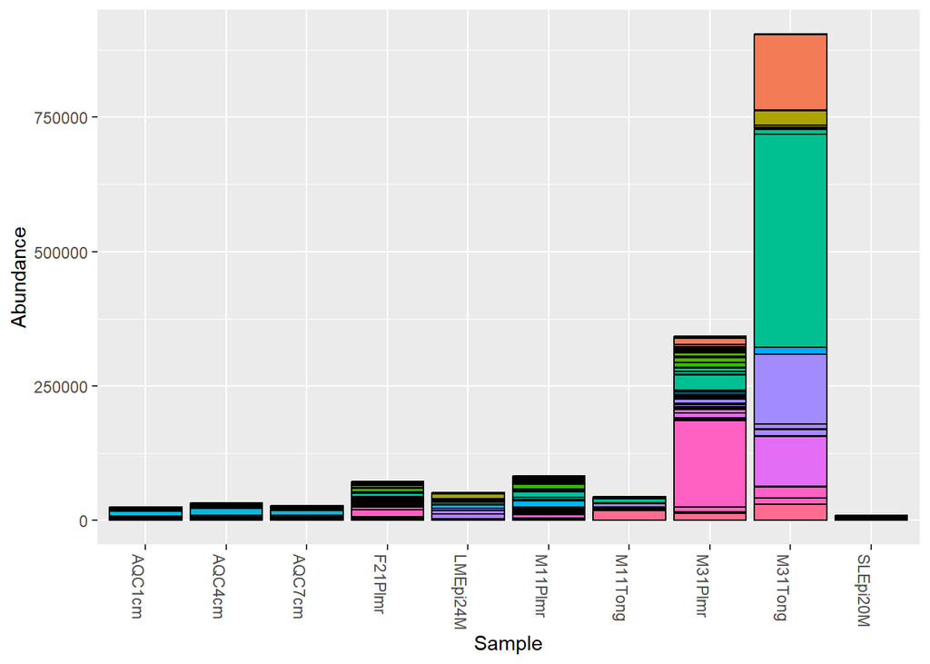

```r
 p = plot_bar(my_physeq, fill = "Species")
 p + theme(legend.position="none")
```

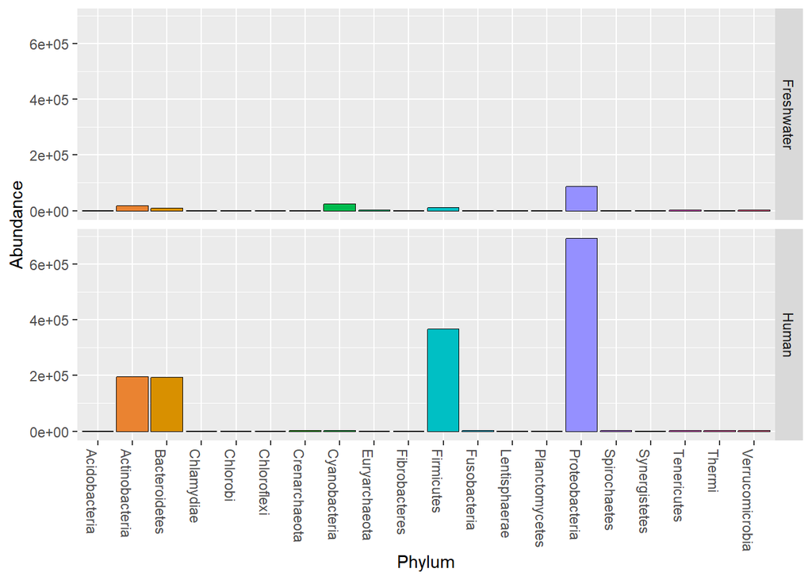

```r
 p = plot_bar(my_physeq, x= "Phylum", fill = "Phylum", facet_grid=SampleOrigin~.)
 p + theme(legend.position="none") + geom_bar(stat = "identity")
```

```r
# To convert to relative abundance
my_physeq_r  = transform_sample_counts(my_physeq, function(x) x / sum(x) )
# Keep the taxa which have a mean values at least 1e-5
my_physeq_rf = filter_taxa(my_physeq_r, function(x) mean(x) > 1e-5, TRUE)
my_physeq_rf
```

```
## phyloseq-class experiment-level object
## otu_table()   OTU Table:         [ 619 taxa and 10 samples ]
## sample_data() Sample Data:       [ 10 samples by 8 sample variables ]
## tax_table()   Taxonomy Table:    [ 619 taxa by 7 taxonomic ranks ]
```